# Applications of Inference Frameworks

Last updated: 2017-01-31

## Notes

## Readings

- Curran-Everett (2009): Explorations in statistics: confidence intervals

## Three frameworks for inference

1. Analytical
2. Maximum likelihood
3. Bayesian

## Inferring a mean

Mean undulation rate for \(n = 8\) gliding snakes (http://www.flyingsnake.org/):

```r
undulation_rate <- c(0.9, 1.2, 1.2, 1.3, 1.4, 1.4, 1.6, 2.0)
```

[figure not shown]

What is the mean undulation rate for this sample of flying snakes?

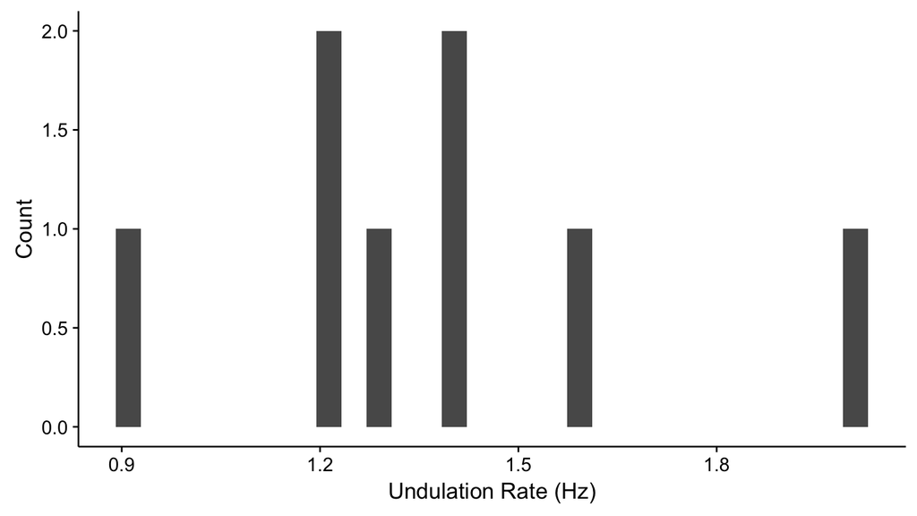

```r
ggplot(data_frame(undulation_rate), aes(undulation_rate)) +
  geom_histogram() +
  labs(x = "Undulation Rate (Hz)", y = "Count")
```

## Analytical inference of mean

Arithmetic mean:

\[\hat{Y} = \frac{\sum_{i=1}^{n}Y_i}{n}\]

\[mean~undulation~rate = \frac{\sum_{i=1}^{n}undulation~rate_i}{n}\]

## Analytical inference of mean

```r
sum(undulation_rate) / length(undulation_rate)
```

```
## [1] 1.375
```

## Maximum likelihood inference of mean

Define a function to calculate the probability of an observed value \(Y_i\) drawn from a [normal distribution](http://mathworld.wolfram.com/NormalDistribution.html) given the mean (\(\mu\)) and standard deviation (\(\sigma\)). Default to the [standard normal distribution](http://mathworld.wolfram.com/StandardNormalDistribution.html) \(\mathcal{N}(0,1)\).

\[f\left(Y_i; \mu, \sigma\right) = \frac{1}{\sqrt{2\pi\sigma^{2}}} e^{\frac{-\left(Y_i-\mu\right)^{2}}{2\sigma^{2}}}\]

```r
normal <- function(Y, mu = 0, sigma = 1) {
  1 / sqrt(2 * pi * sigma ^ 2) *
    exp((-(Y - mu) ^ 2 / (2 * sigma ^ 2)))
}
```

*Note*: this function is built into R as `dnorm()`.

## Test our function

```r
normal(0, mu = 0, sigma = 1)
```

```
## [1] 0.3989423
```

```r
dnorm(0, mean = 0, sd = 1)
```

```
## [1] 0.3989423
```

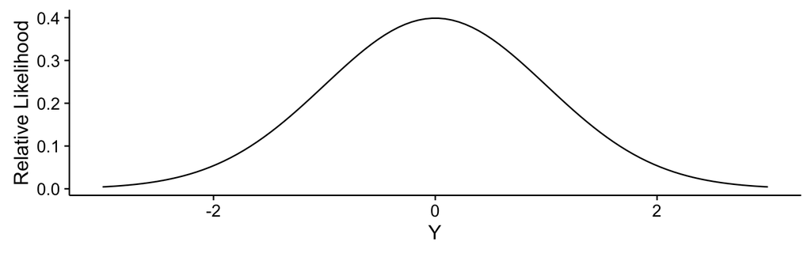

## Calculating a likelihood

If the true mean is 0 and the standard deviation is 1, what is the likelihood of the observed values?

1. This is a model.
2. Calculate the relative likelihood of each observation.
3. Model likelihood is the product of the individual likelihoods.
4. log-likelihood is more tractable, so calculate that.

## Model Likelihood (\(\mathcal{L}\))

For a set of \(Y_i\) and parameters (\(\Theta\); i.e., mean and standard deviation) the likelihood of the model is the product of their individual likelihoods:

\[\mathcal{L}\left(\left\{ Y_{i}\right\} _{i=1}^{n};\Theta\right) = \prod_{i=1}^{n}\phi\left(Y_{i}; \Theta\right)\]

Evaluate the likelihood function for different values of \(\Theta\) to estimate \(\mathcal{L}\) for different sets of \(\Theta\).

- Maximize \(\mathcal{L}\) and you will have the maximum likelihood set of parameter estimates.

## Model Likelihood (\(\mathcal{L}\))

Probabilities are in the range 0 to 1, so taking the product of a large number of probabilities can result in some very small numbers.

- Computers don't handle really small numbers very well
  - There is a lower limit to the smallest number a computer can keep track of.
  - This is \(2.2250739\times 10^{-308}\) in R on the computer that compiled these slides.

Think about computing the model likelihood with thousands or millions of observations.

```r
.50^1000
```

```
## [1] 9.332636e-302
```

## Model Likelihood (\(\mathcal{L}\))

\[\mathcal{L}\left(\left\{ Y_{i}\right\} _{i=1}^{n};\Theta\right) = \prod_{i=1}^{n}\phi\left(Y_{i}; \Theta\right)\]

Log both sides of the equation:

\[\log\left(\mathcal{L}\left(\left\{ Y_{i}\right\} _{i=1}^{n};\Theta\right)\right) = \log\left(\prod_{i=1}^{n}\phi\left(Y_{i};\Theta\right)\right)\]

## Model Likelihood (\(\mathcal{L}\))

Taking advantage of the algebraic rules associated with logs (the log of the products equals the sum of the logs):

\[\log\left(\mathcal{L}\left(\left\{ Y_{i}\right\} _{i=1}^{n};\Theta\right)\right) = \sum_{i=1}^{n} \log\left(\phi\left(Y_{i};\Theta\right)\right)\]

So we just need to sum the log-likelihoods to get the overall model likelihood.

*Note*: `log()` is *natural* log.

## Calculating the log-likelihood for a single combination of \(\mu\) and \(\sigma\)

If the mean is 0 and the standard deviation is 1, what is the likelihood of the observed values?

Likelihood for the first observation (`undulation_rate[1]`):

```r
undulation_rate[1]
```

```
## [1] 0.9
```

```r
normal(undulation_rate[1], mu = 0, sigma = 1)
```

```
## [1] 0.2660852
```

## Calculating the log-likelihood for a single combination of \(\mu\) and \(\sigma\)

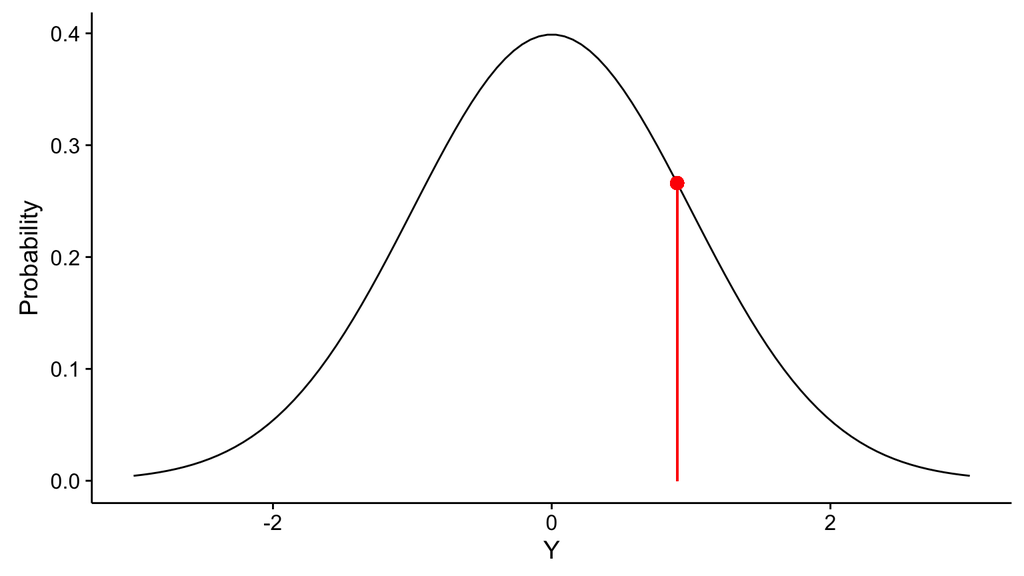

This is only the likelihood for first observation. We need the likelihoods for all 8 undulation rates to get a model likelihood.

## Calculating the log-likelihood for a single combination of \(\mu\) and \(\sigma\)

Vector of likelihoods for all values in `undulation_rate` given `mu = 0` and `sigma = 1`:

```r
(probs <- normal(undulation_rate, mu = 0, sigma = 1))
```

```
## [1] 0.26608525 0.19418605 0.19418605 0.17136859 0.14972747 0.14972747
## [7] 0.11092083 0.05399097
```

Overall likelihood is the product of those likelihoods:

```r
(lik <- prod(probs))
```

```
## [1] 2.308476e-07
```

## Likelihood to log-likelihood

```r
log(lik)
```

```
## [1] -15.28151
```

```r
sum(log(probs))
```

```
## [1] -15.28151
```

For a model in which the mean is 0 and standard deviation is 1, the model log-likelihood is -15.282.

## Higher likelihood

Is there another combination of \(\mu\) and \(\sigma\) that gives a higher likelihood (= larger log-likelihood)?

```r
sum(log(normal(undulation_rate, mu = 1, sigma = 1)))
```

```
## [1] -8.281508
```

## Calculating the log-likelihood for a *range* of \(\mu\) and \(\sigma\)

Find the combination of \(\mu\) and \(\sigma\) that maximizes the log-likelihood of the model for the mean and standard deviation of undulation rates.

Ranges of possible values:

1. Mean (\(\mu\)): \(-\infty < \mu < \infty\)
2. Standard deviation (\(\sigma\)): \(0 < \sigma < \infty\)

## Grid approximation

For combinations of \(\mu\) and \(\sigma\), calculate the model likelihood. Pick the largest log-likelihood as the maximum likelihood estimates.

Set up the grid:

```r
n <- 100
mus <- seq(0.1, 5, length = n)
sigmas <- seq(0.1, 2, length = n)

grid_mu_sigma <- mesh(mus, sigmas)

grid_approx <- data_frame(
  mu = as.numeric(grid_mu_sigma$x),
  sigma = as.numeric(grid_mu_sigma$y),
  log_lik = rep(NA, length = n ^ 2)
)
```

```r
grid_approx
```

```
## # A tibble: 10,000 × 3
##           mu sigma log_lik
##        <dbl> <dbl>   <lgl>
## 1  0.1000000   0.1      NA
## 2  0.1494949   0.1      NA
## 3  0.1989899   0.1      NA
## 4  0.2484848   0.1      NA
## 5  0.2979798   0.1      NA
## 6  0.3474747   0.1      NA
## 7  0.3969697   0.1      NA
## 8  0.4464646   0.1      NA
## 9  0.4959596   0.1      NA
## 10 0.5454545   0.1      NA
## # ... with 9,990 more rows
```

## Grid approximation

```r
for (i in 1:nrow(grid_approx)) {
  grid_approx[i, 3] <-
    sum(log(normal(undulation_rate,
                   mu = grid_approx$mu[i],
                   sigma = grid_approx$sigma[i])))
}
```

```r
head(grid_approx)
```

```
## # A tibble: 6 × 3
##          mu sigma   log_lik
##       <dbl> <dbl>     <dbl>
## 1 0.1000000   0.1 -675.9308
## 2 0.1494949   0.1 -626.4259
## 3 0.1989899   0.1 -578.8807
## 4 0.2484848   0.1 -533.2954
## 5 0.2979798   0.1 -489.6698
## 6 0.3474747   0.1 -448.0041
```

This approach is coarse and time consuming. For \(n = 100\), there are 10000 comparisons.

## Grid approximation

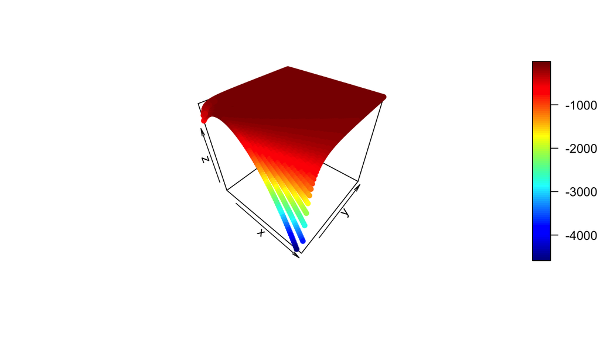

## Grid approximation

On this grid, the maximum likelihood estimates of \(\mu\) and \(\sigma\) are:

```r
grid_approx[which.max(grid_approx$log_lik), ]
```

```
##            mu     sigma   log_lik
## 1127 1.386869 0.3111111 -1.813363
```

## Maximum likelihood via optimization

Search for the most likely values of \(\mu\) and \(\sigma\)?

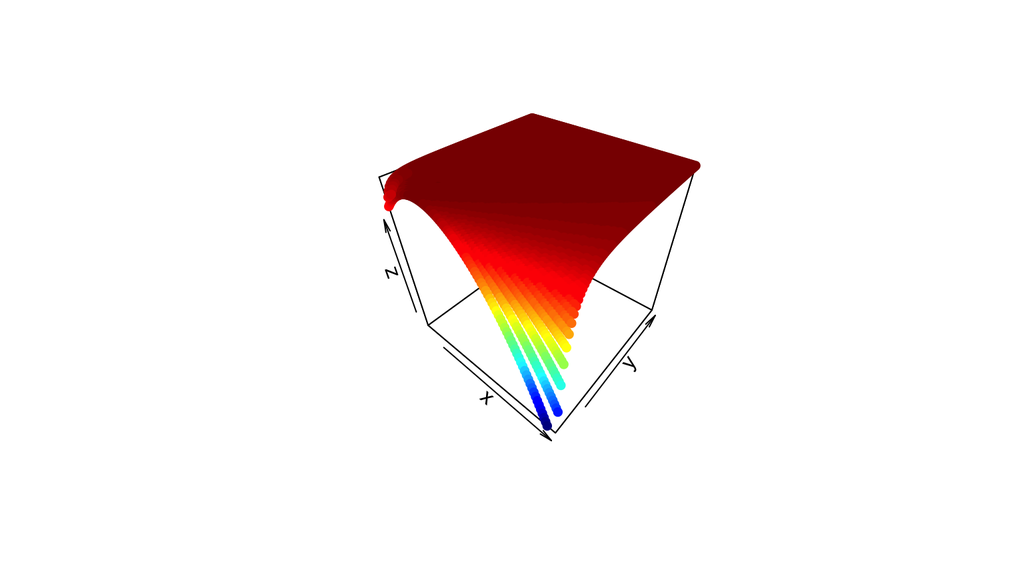

## Maximum likelihood via optimization

Define a function that takes a vector of values to optimize `x` (\(\mu\) and \(\sigma\)) as well as a set of data `Y` and returns the log-likelihood:

```r
log_lik <- function(x, Y){
  probs <- normal(Y, mu = x[1], sigma = x[2])
  return(sum(log(probs)))
}
```

We can now jointly optimize \(\mu\) and \(\sigma\), maximizing the log-likelihood.

## Maximum likelihood via optimization

```r
optim(c(0.1, 0.1), # Start at 0.1, 0.1
      log_lik,
      Y = undulation_rate,
      control = list(fnscale = -1,
                     reltol = 10^-100))
```

```
## $par
## [1] 1.3750000 0.3031089
##
## $value
## [1] -1.802203
##
## $counts
## function gradient
##      287       NA
##
## $convergence
## [1] 0
##
## $message
## NULL
```

## Maximum likelihood via optimization

```r
fm <- glm(undulation_rate ~ 1)
coef(fm)
```

```
## (Intercept)
##       1.375
```

```r
logLik(fm)
```

```
## 'log Lik.' -1.802203 (df=2)
```

## Bayesian inference of the mean

Ranges of possible maximum likelihood values:

1. \(\mu\): \(-\infty < \mu < \infty\)
2. \(\sigma\): \(0 < \sigma < \infty\)

Drawbacks:

1. \(\mu\) can't be negative (no negative undulation rates) and probably isn't a large number
2. \(\sigma\) is also probably not huge either

Can we do better? Yes, Bayesian priors.

## Prior for the mean

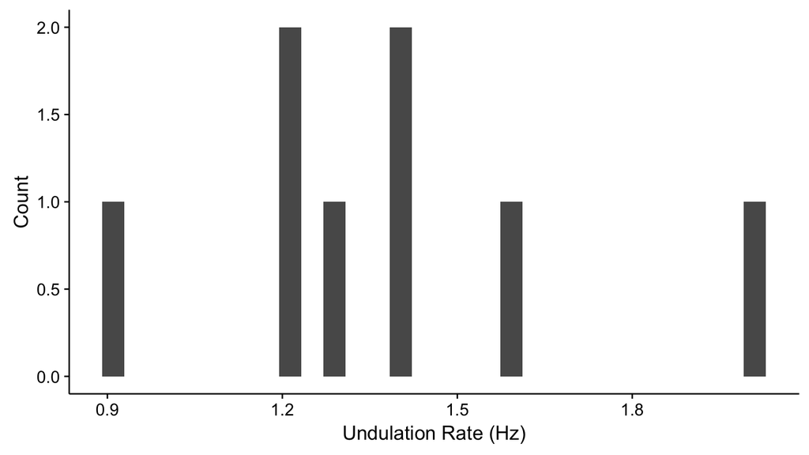

## Prior for the mean

Cauchy distribution (location = 0, scale = 5)

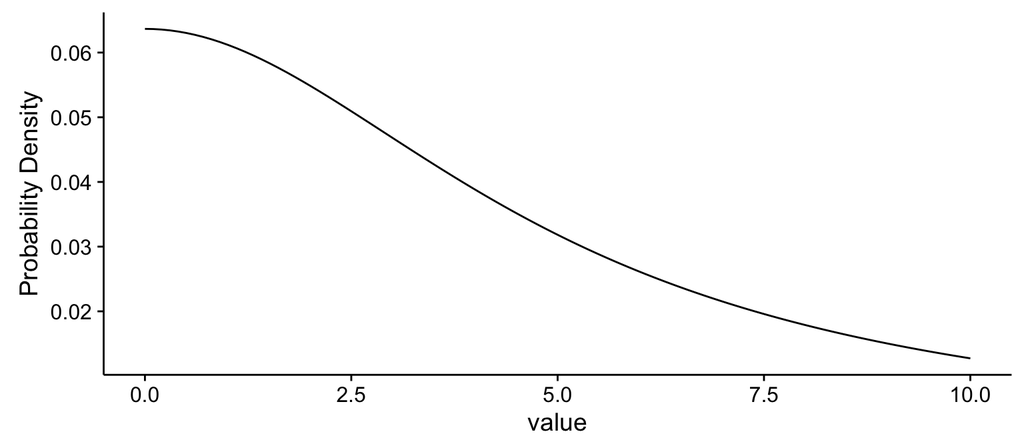

## Bayesian model

[stan](http://mc-stan.org/) code:

```r
model <- "
  data{
    int<lower=1> N;
    real undulation_rate[N];
  }
  parameters{
    real<lower=0> mu;
    real<lower=0> sigma;
  }
  model{
    sigma ~ cauchy(0, 5);
    mu ~ cauchy(0, 5);
    undulation_rate ~ normal(mu, sigma);
  }
"
```

## Sample the Bayesian model

```r
fm_priors <- stan(
  model_code = model,
  data = list(undulation_rate = undulation_rate,
              N = length(undulation_rate)),
  iter = 10^4,
  warmup = 10^3,
  seed = 12)
```

[output not shown]

[output cut: 16 more lines]

[output not shown]

## Inspecting the samples

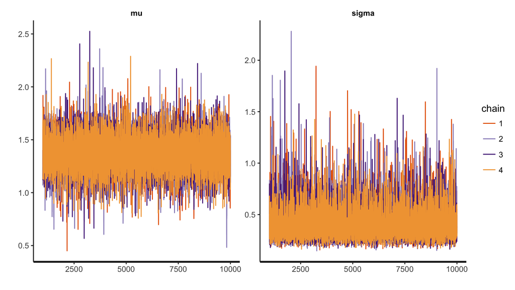

## Summarizing the results

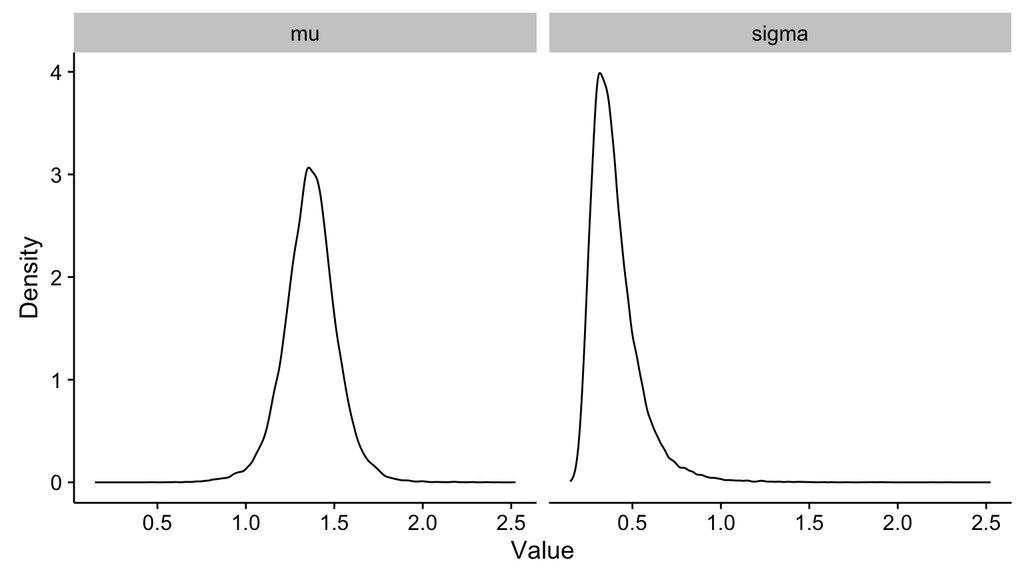

## Summarizing the results

```
## Inference for Stan model: 339acd0649a290bdec1497a993a2112f.
## 4 chains, each with iter=10000; warmup=1000; thin=1;
## post-warmup draws per chain=9000, total post-warmup draws=36000.
##
##        mean se_mean    sd   2.5%   25%   50%   75% 97.5% n_eff  Rhat
## mu    1.365   0.001 0.151  1.058 1.275 1.366 1.454 1.666 14465 1.000
## sigma 0.402   0.001 0.144  0.225 0.306 0.371 0.459 0.764 11001 1.000
## lp__  3.151   0.013 1.169 -0.033 2.707 3.500 3.985 4.288  8687 1.001
##
## Samples were drawn using NUTS(diag_e) at Tue Jan 31 21:28:33 2017.
## For each parameter, n_eff is a crude measure of effective sample size,
## and Rhat is the potential scale reduction factor on split chains (at
## convergence, Rhat=1).
```

We get a lower mean than the analytical or ML estimate (1.375) because the prior places more probability on lower values.

## Reference

Curran-Everett, D. 2009. Explorations in Statistics: Confidence Intervals. *AJP: Advances in Physiology Education* 33:87–90.